# Model Evaluation: Regression

อ.ดร.สิวะโชติ ศรีสุทธิยากร

9/1/2020

บทเรียนนี้จะกล่าวถึง cross-validation technique ที่ใช้สำหรับตรวจสอบประสิทธิภาพของโมเดลการเรียนรู้ที่พัฒนาขึ้น เนื้อหาในบทเรียนนี้จะกล่าวถึงมโนทัศน์พื้นฐานของการตรวจสอบประสิทธิภาพโมเดลการเรียนรู้ ดัชนีประสิทธิภาพของโมเดล และเทคนิค cross-validation รายละเอียดมีดังนี้

# **มโนทัศน์พื้นฐาน**

ปัญหาหนึ่งที่สำคัญในการพัฒนาโมเดลการเรียนรู้ของเครื่องคือปัญหาโมเดลสอดคล้องกับข้อมูลเกินพอดี (overfitting) ปํญหาดังกล่าวเกิดขึ้นเมื่อโมเดลการเรียนรู้ที่พัฒนาขึ้นไม่ว่าจะเป็น classification model หรือ regression model สามารถเรียนรู้ความสัมพันธ์ระหว่างตัวแปรในชุดข้อมูลฝึกหัดได้ดีมากเกินไปจนทำให้ความสามารถของโมเดลในการทำนายข้อมูลอื่น ๆ ที่อยู่นอกเหนือจากชุดข้อมูลฝึกหัดมีจำกัดหรือต่ำมากจนเกินไป ซึ่งทำให้โมเดลการเรียนรู้ที่พัฒนาขึ้นขาดคุณสมบัติความเป็นนัยทั่วไปของโมเดล (generalizability) วิธีการที่ช่วยลดทอนหรือป้องกันการเกิดปัญหา overfitting ของโมเดลคือการพัฒนาโมเดลการเรียนรู้โดยวิเคราะห์ประสิทธิภาพของโมเดลโดยใช้เทคนิค cross-validation ที่มีการแบ่งข้อมูลที่ผู้วิเคราะห์มีออกเป็นสองส่วน ส่วนแรกคือ **ชุดข้อมูลฝึกหัด (training data)** และส่วนที่สองคือ **ชุดข้อมูลทดสอบ (testing data)**

ชุดข้อมูลฝึกหัดจะใช้สำหรับเป็นตัวอย่างให้โมเดลการเรียนรู้ของเครื่องต่าง ๆ ได้เรียนรู้ความสัมพันธ์ระหว่างตัวแปรและสร้างโมเดลทางคณิตศาสตร์ที่มีความสามารถในการเลียนแบบความสัมพันธ์ในชุดข้อมูลดังกล่าว ประสิทธิภาพของโมเดลการเรียนรู้ที่คำนวณจากชุดข้อมูลฝึกหัดนี้สามารถใช้สะท้อนระดับความลำเอียง (bias) ของโมเดลที่พัฒนาขึ้นได้ อย่างไรก็ตามในบางครั้งโมเดลที่มีระดับความลำเอียงต่ำมาก ๆ ก็ไม่ใช่โมเดลที่ดีเสมอไป ทั้งนี้เป็นเพราะโมเดลดังกล่าวมีความสอดคล้องกับข้อมูลในชุดข้อมูลฝึกหัดมากจนเกินไปจนทำให้ไม่สามารถนำไปทำนายค่าสังเกตอื่นที่อยู่นอกเหนือชุดข้อมูลฝึกหัดได้ การตรวจสอบประสิทธิภาพของโมเดลโดยใช้ชุดข้อมูลทดสอบจึงมีความจำเป็น เนื่องจากข้อมูลในชุดข้อมูลทดสอบนี้เป็นข้อมูลที่โมเดลที่พัฒนาขึ้นยังไม่เคยเรียนรู้มาก่อน ประสิทธิภาพที่คำนวณได้จากชุดข้อมูลทดสอบนี้จึงสะท้อนคุณสมบัติของโมเดลในด้านความเป็นนัยทั่วไปในการทำนาย

# **ดัชนีวัดประสิทธิภาพของโมเดล (model performance metric)**

บทเรียนนี้จะกล่าวถึงสถิติ 3 ตัวที่มักนิยมใช้เป็นดัชนีวัดประสิทธิภาพในการทำนายของโมเดล ได้แก่

1. **สัมประสิทธิ์การตัดสินใจ (coefficient of determination: $R^2$)** มีค่าเท่ากับกำลังสองของสัมประสิทธิ์สหสัมพันธ์ระหว่างค่าทำนายกับค่าจริง ทำให้มีค่าที่เป็นไปได้อยู่ในช่วง $[0,1]$ ซึ่งมีความหมายเป็นร้อยละของปริมาณความผันแปรที่มีร่วมกันระหว่างค่าทำนายที่ได้จากโมเดลกับค่าจริง โมเดลที่มีค่า $R^2$ เข้าใกล้ 1 แสดงว่ามีประสิทธิภาพในการทำนายสูง
2. **รากที่สองของความคลาดเคลื่อนกำลังสอง (root mean squares error: $RMSE$)** มีสูตรการคำนวณดังนี้

$$RMSE=\sqrt{\frac{\sum_{i=1}^n(y_i-\hat{y}_i)^2}{n}}$$
เมื่อ $y_i$ คือค่าสังเกตจริงในชุดข้อมูลทดสอบ, $\hat{y}_i$ คือค่าทำนายของค่าสังเกตในชุดข้อมูลทดสอบที่ได้จากโมเดลการเรียนรู้ และ $n$ คือขนาดของชุดข้อมูลทดสอบ ดัชนี $RMSE$ สะท้อนปริมาณความคลาดเคลื่อนในการทำนายของโมเดลโดยเฉลี่ย โมเดลที่มีค่า $RMSE$ ต่ำแสดงว่ามีประสิทธิภาพในการทำนายสูง

3. **ส่วนเบี่ยงเบนเฉลี่ยของความคลาดเคลื่อน (absolute mean error: $MAE$)** มีสูตรการคำนวณดังนี้

$$MAE=\frac{\sum_{i=1}^n|y_i-\hat{y}_i|}{n}$$
จากสูตรข้างต้นจะเห็นว่า $MAE$ มีความหมายเหมือนกับ $RMSE$ แต่มีการใช้ค่าสัมบูรณ์แทนการยกกำลังสอง จึงทำให้ดัชนี $MAE$ มีความแกร่งคือค่าทำนายที่ผิดปกติมากกว่า $RMSE$

# **Cross-validation**

โดยทั่วไปกระบวนการพัฒนาและตรวจสอบประสิทธิภาพของโมเดลด้วยเทคนิค cross-validation จะประกอบด้วยขั้นตอนใหญ่ ๆ ดังนี้

1. พัฒนาโมเดลโดยใช้ชุดข้อมูลฝึกหัด
2. ใช้โมเดลที่พัฒนาขึ้นเพื่อทำนายค่าสังเกตในชุดข้อมูลทดสอบ
3. คำนวณประสิทธิภาพของโมเดลในชุดข้อมูลทดสอบ

เทคนิค cross-validation ยังอาจจำแนกได้เป็น 4 ประเภท ตามลักษณะของการแบ่งข้อมูล ดังนี้

**(1) train/test method** วิธีการนี้เป็นวิธีการดั้งเดิม กล่าวคือทำการแบ่งชุดข้อมูลที่มีออกเป็น 2 ส่วนได้แก่ ชุดข้อมูลฝึกหัด และชุดข้อมูลทดสอบ ตามอัตราส่วนที่กำหนดเช่น 80:20, 70:30, 60:40 หรือ 50:50 เป็นต้น

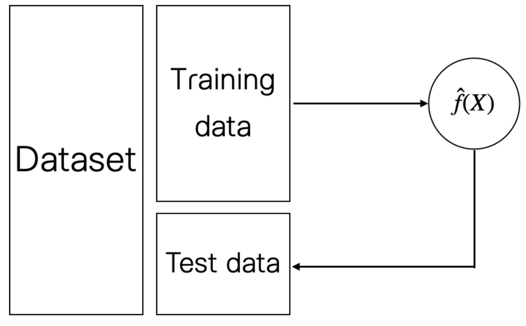

ตัวอย่างต่อไปนี้แสดงการตรวจสอบประสิทธิภาพของโมเดลโดยใช้ train/test method ใช้ข้อมูลที่ใช้เป็นตัวอย่างคือชุดข้อมูล state.x77 ที่เก็บรวบรวมข้อมูลอัตราการฆาตกรรม (Murder) กับสภาพทางเศรษฐกิจ สังคม และภูมิศาสตร์ของแต่ละรัฐในประเทศอเมริกา

```r
dat<-data.frame(state.x77) #import and convert data into data.frame
str(dat) #exploring dat
```

```
## 'data.frame':    50 obs. of  8 variables:
##  $ Population: num  3615 365 2212 2110 21198 ...
##  $ Income    : num  3624 6315 4530 3378 5114 ...
##  $ Illiteracy: num  2.1 1.5 1.8 1.9 1.1 0.7 1.1 0.9 1.3 2 ...
##  $ Life.Exp  : num  69 69.3 70.5 70.7 71.7 ...
##  $ Murder    : num  15.1 11.3 7.8 10.1 10.3 6.8 3.1 6.2 10.7 13.9 ...
##  $ HS.Grad   : num  41.3 66.7 58.1 39.9 62.6 63.9 56 54.6 52.6 40.6 ...
##  $ Frost     : num  20 152 15 65 20 166 139 103 11 60 ...
##  $ Area      : num  50708 566432 113417 51945 156361 ...
```

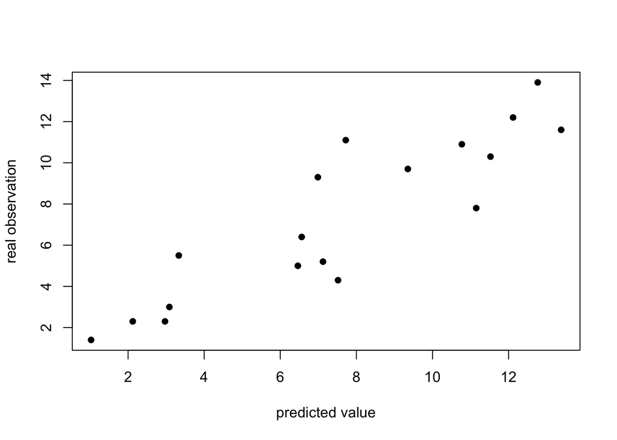

```r
library(caret)
train.id<-createDataPartition(dat$Murder,p=0.6,list=F) #split the data
train.dat<-dat[train.id,] #training dataset
test.dat<-dat[-train.id,] #testing dataset

#trainthe regression model using lm() function
fit<-lm(Murder~., data=train.dat)

#calculate predictions and compute performance metric from testing data
pred<-predict(fit,test.dat)
# plot scatter plot between prediction and real value
plot(pred,test.dat$Murder,xlab="predicted value",ylab="real observation",pch=16)
```

**Performance metric**

```r
# performance metric
performance<-data.frame(R2(pred,test.dat$Murder),
                        RMSE(pred,test.dat$Murder),
                        MAE(pred,test.dat$Murder))
names(performance)<-c("R2","RMSE","MAE")
performance
```

```
##          R2     RMSE      MAE
## 1 0.7988651 1.757955 1.332139
```

วิธี train/test เป็นวิธีที่มีประสิทธิภาพดีในกรณีที่ผู้วิเคราะห์มีข้อมูลจำนวนมาก อย่างไรก็ตามวิธีการนี้ก็มีข้อสังเกตคือ โมเดลทำนายที่พัฒนาขึ้นพัฒนาจากข้อมูลในชุดข้อมูลฝึกหัดซึ่งเป็นข้อมูลเพียงบางส่วนของข้อมูลทั้งหมด จึงอาจทำให้โมเดลเกิดความลำเอียงได้ โดยเฉพาะในกรณีที่ข้อมูลมีจำนวนไม่มาก

**(2) Leave one out cross validation (LOOCV)** วิธีการนี้แบ่งข้อมูลออกเป็นสองส่วนเช่นเดียวกับวิธีการ train/test แต่มีความแตกต่างตรงลักษณะของการแบ่ง กล่าวคือวิธีการนี้จะแบ่งข้อมูล 1 ค่าไว้เป็นข้อมูลทดสอบ จากนั้นใช้ข้อมูลที่เหลือทั้งหมดเพื่อพัฒนาโมเดลสำหรับทำนายข้อมูล 1 ค่าในข้างต้น และเก็บผลประสิทธิภาพการทำนายข้อมูลดังกล่าวไว้ จากนั้นดำเนินกระบวนการข้างต้นซ้ำจนกว่าจะทดสอบข้อมูลครบทุกค่า และแล้วจึงคำนวณประสิทธิภาพของโมเดลจากค่าประสิทธิภาพการทำนายของข้อมูลที่เก็บไว้

ตัวอย่างต่อไปนี้แสดงการวิเคราะห์ประสิทธิภาพของโมเดลแบบ Leave one out cross validation โดยใช้ฟังก์ชัน `train()` ใน package-caret โดยใช้ข้อมูล `state.x77` ในข้างต้น

```r
# specify training control
train.clt<-trainControl(method="LOOCV")

# train the regression model using train() function
fit<-train(Murder~., data=dat,method="lm", trControl=train.clt)

#print the LOOCV results
fit
```

```
## Linear Regression
##
## 50 samples
##  7 predictor
##
## No pre-processing
## Resampling: Leave-One-Out Cross-Validation
## Summary of sample sizes: 49, 49, 49, 49, 49, 49, ...
## Resampling results:
##
##   RMSE      Rsquared   MAE
##   2.004621  0.7115175  1.621311
##
## Tuning parameter 'intercept' was held constant at a value of TRUE
```

```r
#regression output
summary(fit)
```

```
##
## Call:
## lm(formula = .outcome ~ ., data = dat)
##
## Residuals:
##     Min      1Q  Median      3Q     Max
## -3.4452 -1.1016 -0.0598  1.1758  3.2355
##
## Coefficients:
##               Estimate Std. Error t value Pr(>|t|)
## (Intercept)  1.222e+02  1.789e+01   6.831 2.54e-08 ***
## Population   1.880e-04  6.474e-05   2.905  0.00584 **
## Income      -1.592e-04  5.725e-04  -0.278  0.78232
## Illiteracy   1.373e+00  8.322e-01   1.650  0.10641
## Life.Exp    -1.655e+00  2.562e-01  -6.459 8.68e-08 ***
## HS.Grad      3.234e-02  5.725e-02   0.565  0.57519
## Frost       -1.288e-02  7.392e-03  -1.743  0.08867 .
## Area         5.967e-06  3.801e-06   1.570  0.12391
## ---
## Signif. codes:  0 '***' 0.001 '**' 0.01 '*' 0.05 '.' 0.1 ' ' 1
##
## Residual standard error: 1.746 on 42 degrees of freedom
## Multiple R-squared:  0.8083, Adjusted R-squared:  0.7763
## F-statistic: 25.29 on 7 and 42 DF,  p-value: 3.872e-13
```

วิธี LOOCV มีข้อดีคือโมเดลทำนายถูกพัฒนาข้อมูลทั้งหมดที่มี จึงทำให้โมเดลทำนายที่ได้มีความลำเอียงต่ำ อย่างไรก็ตามวิธีการนี้มีข้อจำกัดคือใช้ทรัพยากรในการคำนวณที่ค่อนข้างมาก โดยเฉพาะในกรณีที่ชุดข้อมูลมีขนาดใหญ่ นอกจากนี้วิธีการนี้ยังมีความไวต่อค่าทำนายที่ผิดปกติอีกด้วย

**(3) K-fold cross-validation**

วิธีการนี้แตกต่างจาก LOOCV ตรงทีมีการแบ่งชุดข้อมูลออกเป็น k ส่วน ที่เรียกว่า k-fold จากนั้นเก็บข้อมูล 1 ชุดไว้เพื่อใช้ทดสอบประสิทธิภาพของโมเดล และใช้ชุดข้อมูล k-1 ชุดที่เหลือเพื่อพัฒนาโมเดลทำนายสำหรับทำนายค่าสังเกตในชุดข้อมูลที่เก็บไว้ในข้างต้น จากนั้นดำเนินกระบวนการข้างต้นซ้ำเพื่อสลับระหว่างชุดข้อมูลทดสอบ และชุดข้อมูลฝึกหัดจนครบ แล้วจึงคำนวณค่าประสิทธิภาพของโมเดลจากดัชนีวัดประสิทธิภาพจำนวน k ค่า รูปต่อไปนี้แสดงกระบวนการ 3-fold cross validation

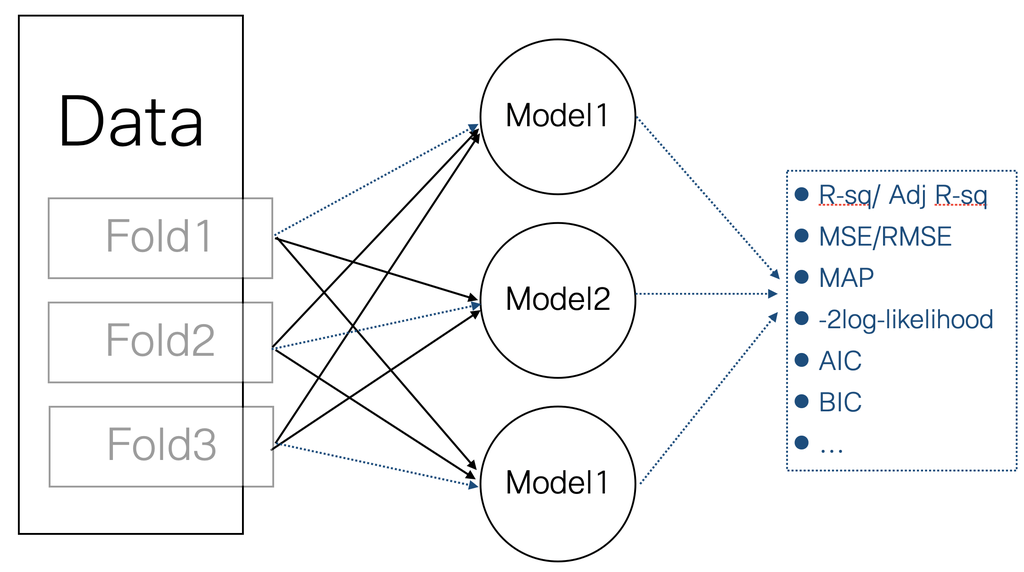

```r
# specify the train control
train.clt<-trainControl(method="cv", number=10)

# train the regression model using train() function
fit<-train(Murder~., data=dat, method="lm", trControl=train.clt)

# print the CV results
fit
```

```
## Linear Regression
##
## 50 samples
##  7 predictor
##
## No pre-processing
## Resampling: Cross-Validated (10 fold)
## Summary of sample sizes: 45, 44, 45, 44, 45, 46, ...
## Resampling results:
##
##   RMSE      Rsquared   MAE
##   1.978332  0.7731903  1.65895
##
## Tuning parameter 'intercept' was held constant at a value of TRUE
```

วิธีการนี้หากกำหนดให้จำนวน k มีค่ามากขึ้นเรื่อย ๆ ผลการวิเคราะห์ที่ได้จะมีค่าลู่เข้าหาวิธีการ LOOCV นอกจากนี้โมเดลทำนายที่ได้จะมีความลำเอียงลดลงตามจำนวน k ที่เพิ่มขึ้น อย่างไรก็ตามจากการวิจัยที่ผ่านมาพบว่า การกำหนดจำนวน k ที่เหมาะสมอาจกำหนดให้อยู่ในช่วงตั้งแต่ 5 ถึง 10 (ไม่ได้มีกฎเกณฑ์ตายตัว) Molinaro (2005) ทำการเปรียบเทียบประสิทธิภาพระหว่างเทคนิค LOOCV กับ 10-fold CV พบว่าให้ผลที่ไม่แตกต่างกัน แต่ประสิทธิภาพในการคำนวณของเทคนิค CV สามารถทำได้ไวกว่า นอกจากนี้ยังพบว่าการกำหนด k=2 หรือ k=3 ก่อให้เกิด bias ในการประมาณค่าประสิทธิภาพของโมเดลสูงมาก

**(4) Repeated K-fold cross-validation**

เทคนิค repeated k-fold CV สามารถใช้เพื่อเสริมประสิทธิภาพให้กับเทคนิค CV ได้ เทคนิคนี้เป็นการทำ k-fold cross validation ซ้ำได้หลาย ๆ ครั้ง ซึ่งช่วยลดความลำเอียงของเทคนิค CV ในกรณีที่กำหนดให้ k มีจำนวนน้อย ๆ

```r
train.clt<-trainControl(method="repeatedcv", number=5, repeats=5)
fit<-train(Murder~., data=dat, method="lm", trControl=train.clt)
fit
```

```
## Linear Regression
##
## 50 samples
##  7 predictor
##
## No pre-processing
## Resampling: Cross-Validated (5 fold, repeated 5 times)
## Summary of sample sizes: 40, 39, 40, 41, 40, 40, ...
## Resampling results:
##
##   RMSE      Rsquared   MAE
##   1.928621  0.7599003  1.607337
##
## Tuning parameter 'intercept' was held constant at a value of TRUE
```